# COG Text Analysis Workshop

Camille Johnston

2024-07-10

# Load Packages

```r
library(tidyverse) ## Always load tidyverse
library(tidytext) ## Amazing package for all things text analysis
library(tidymodels) ## Modeling framework
library(textrecipes) ## Helpful feature engineering for text data
library(rstudioapi) ## set working directory
library(LiblineaR) ## for SVM models
library(ranger) ## for random forest models
library(xgboost) ## for XGBoost models
```

# Load data

from https://www.kaggle.com/datasets/schmoyote/coffee-reviews-dataset?select=coffee_analysis.csv, I cleaned it up a little bit beforehand

```r
## Set working directory to wherever this script is
setwd(dirname(getActiveDocumentContext()$path))

## Load in csv from that path
coffee <- read.csv("coffee.csv")
```

# Exploring our data

Let’s take a look at our data!

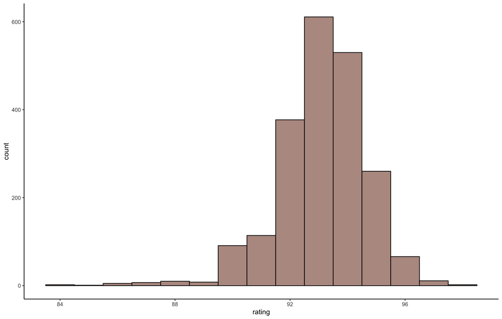

```r
## What's our overall distribution of ratings?
coffee %>%
  ggplot(aes(rating)) +
  geom_histogram(binwidth = 0.999999, color = "black", fill = "#B79990") +
  theme_classic()
```

```r
## Unnest tokens for plots
tidy_coffee <- coffee %>%
  unnest_tokens(word, review)

## Basic look at most common words
tidy_coffee %>%
  count(word, sort = TRUE) %>%
  slice_head(n = 50)
```

```
##         word    n
## 1        and 6662
## 2       with 3829
## 3         in 3755
## 4        cup 3339
## 5      sweet 3316
## 6          a 2762
## 7      toned 2709
## 8        the 2453
## 9         of 2452
## 10     aroma 2122
## 11 mouthfeel 2108
## 12    finish 2102
## 13 chocolate 2047
## 14     notes 1916
```

[output cut: 36 more lines]

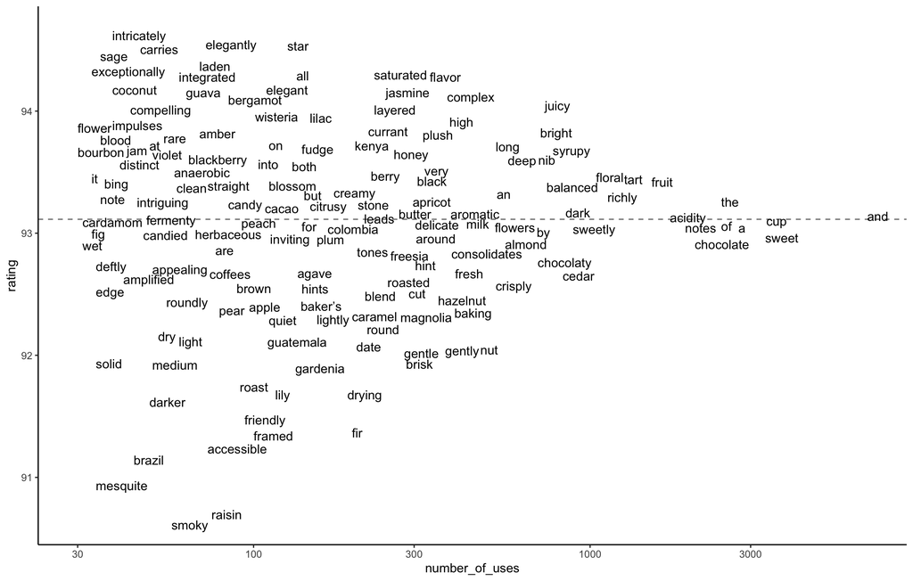

```r
## On average, which words are used for higher vs. lower scores
tidy_coffee %>%
  ## Group data by word
  group_by(word) %>%
  ## Count the number of occurrences and average rating associated with each word
  summarise(number_of_uses = n(),
            rating = mean(rating)) %>%
  ## Filter out words that appear fewer than 30 times
  filter(number_of_uses >= 30) %>%
  ## Set up the ggplot with uses on the x-axis and rating on the y-axis
  ggplot(aes(number_of_uses, rating)) +
  ## Add a horizontal line at the overall mean rating
  geom_hline(yintercept = mean(coffee$rating), lty = 2, color = "gray50") +
  ## Add text labels for each word, avoiding overlap
  geom_text(aes(label = word), check_overlap = TRUE, vjust = "top", hjust = "left") +
  ## Use a logarithmic scale for the x-axis
  scale_x_log10() +
  ## Yse classic theme
  theme_classic()
```

# Set up our “data budget”

A data budget refers to the careful allocation of a dataset into different parts for training, testing, and validation. This ensures that the model can be trained and evaluated effectively, preventing overfitting and ensuring that the model generalizes well to unseen data.

Note: we’ll use cross-validation folds here, but you could always use `bootstraps()` instead of `vfold_cv()` if you would prefer that approach. (Uses replacement, good for small datasets)

```r
## Set seed for reproducibility
set.seed(123)

## Split data into training and testing sets
## Stratifying by the 'rating' distribution of ratings in both sets
coffee_split <- initial_split(coffee, strata = rating)
coffee_train <- training(coffee_split)
coffee_test <- testing(coffee_split)

## Set another seed for reproducibility (this is what the experts do, idk why)
set.seed(234)
## Create cross-validation folds from the training set for model evaluation
coffee_folds <- vfold_cv(coffee_train, strata = rating)
## View folds
coffee_folds
```

```
## #  10-fold cross-validation using stratification
## # A tibble: 10 × 2
##    splits             id
##    <list>             <chr>
##  1 <split [1411/159]> Fold01
##  2 <split [1412/158]> Fold02
##  3 <split [1412/158]> Fold03
##  4 <split [1412/158]> Fold04
##  5 <split [1413/157]> Fold05
##  6 <split [1413/157]> Fold06
##  7 <split [1413/157]> Fold07
##  8 <split [1414/156]> Fold08
##  9 <split [1415/155]> Fold09
## 10 <split [1415/155]> Fold10
```

# Set up feature engineering recipes

Feature engineering is the process of creating features (i.e., input variables) for you machine learning model. In this context, we are creating features from text data using techniques like tokenization, TF/TF-IDF, and normalization. Later on, we’ll compare these approaches to see which one performs best.

```r
## Recipe 1: tokenizing text and computing TF-IDF features for top 500 words
coffee_rec_tfidf <-
  recipe(rating ~ review, data = coffee_train) %>%
  step_tokenize(review) %>%
  step_tokenfilter(review, max_tokens = 500) %>%
  step_tfidf(review)

## Recipe 2: tokenizing text and computing TF features for top 500 words
coffee_rec_tf <-
  recipe(rating ~ review, data = coffee_train) %>%
  step_tokenize(review) %>%
  step_tokenfilter(review, max_tokens = 500) %>%
  step_tf(review)

## Recipe 3: tokenizing text, computing TF-IDF features for top 500 words,
##  and also removing stopwords and normalizing all predictor variables
coffee_rec_tfidf_stop_norm <-
  recipe(rating ~ review, data = coffee_train) %>%
  step_tokenize(review) %>%
  step_stopwords(review) %>%
  step_tokenfilter(review, max_tokens = 500) %>%
  step_tfidf(review) %>%
  step_normalize(all_predictors())


## Check that these steps are working (not required)
prep(coffee_rec_tfidf) %>% bake(new_data = NULL)
```

```
## # A tibble: 1,570 × 501
##    rating tfidf_review_a tfidf_review_accessible tfidf_review_acidity
##     <int>          <dbl>                   <dbl>                <dbl>
##  1     90         0.0106                  0                    0
##  2     92         0.0249                  0                    0
##  3     91         0.0152                  0                    0
##  4     87         0.0317                  0                    0
##  5     92         0.0704                  0                    0
##  6     89         0.0141                  0                    0
##  7     92         0.0346                  0                    0
##  8     92         0                       0                    0.0135
##  9     89         0.0131                  0                    0
## 10     92         0.0241                  0.0529               0
## # ℹ 1,560 more rows
## # ℹ 497 more variables: tfidf_review_agave <dbl>, tfidf_review_aged <dbl>,
## #   tfidf_review_akin <dbl>, tfidf_review_all <dbl>, tfidf_review_almond <dbl>,
## #   tfidf_review_almost <dbl>, tfidf_review_also <dbl>,
## #   tfidf_review_amber <dbl>, tfidf_review_amplified <dbl>,
## #   tfidf_review_an <dbl>, tfidf_review_anaerobic <dbl>,
## #   tfidf_review_anaerobically <dbl>, tfidf_review_and <dbl>, …
```

```r
prep(coffee_rec_tf) %>% bake(new_data = NULL)
```

```
## # A tibble: 1,570 × 501
##    rating tf_review_a tf_review_accessible tf_review_acidity tf_review_agave
##     <int>       <int>                <int>             <int>           <int>
##  1     90           1                    0                 0               0
##  2     92           2                    0                 0               0
##  3     91           1                    0                 0               0
##  4     87           2                    0                 0               0
##  5     92           5                    0                 0               0
##  6     89           1                    0                 0               0
##  7     92           2                    0                 0               0
##  8     92           0                    0                 1               0
##  9     89           1                    0                 0               0
## 10     92           2                    1                 0               0
## # ℹ 1,560 more rows
## # ℹ 496 more variables: tf_review_aged <int>, tf_review_akin <int>,
## #   tf_review_all <int>, tf_review_almond <int>, tf_review_almost <int>,
## #   tf_review_also <int>, tf_review_amber <int>, tf_review_amplified <int>,
## #   tf_review_an <int>, tf_review_anaerobic <int>,
## #   tf_review_anaerobically <int>, tf_review_and <int>,
## #   tf_review_animated <int>, tf_review_appealing <int>, …
```

```r
prep(coffee_rec_tfidf_stop_norm) %>% bake(new_data = NULL)
```

```
## # A tibble: 1,570 × 501
##    rating tfidf_review_accessible tfidf_review_acidity tfidf_review_agave
##     <int>                   <dbl>                <dbl>              <dbl>
##  1     90                  -0.189              -1.60               -0.245
##  2     92                  -0.189              -1.60               -0.245
##  3     91                  -0.189              -1.60               -0.245
##  4     87                  -0.189              -1.60               -0.245
##  5     92                  -0.189              -1.60               -0.245
##  6     89                  -0.189              -1.60               -0.245
##  7     92                  -0.189              -1.60               -0.245
##  8     92                  -0.189               0.0763             -0.245
##  9     89                  -0.189              -1.60               -0.245
## 10     92                   4.21               -1.60               -0.245
## # ℹ 1,560 more rows
## # ℹ 497 more variables: tfidf_review_aged <dbl>, tfidf_review_akin <dbl>,
## #   tfidf_review_almond <dbl>, tfidf_review_almost <dbl>,
## #   tfidf_review_also <dbl>, tfidf_review_amber <dbl>,
## #   tfidf_review_amplified <dbl>, tfidf_review_anaerobic <dbl>,
## #   tfidf_review_anaerobically <dbl>, tfidf_review_animated <dbl>,
## #   tfidf_review_appealing <dbl>, tfidf_review_apple <dbl>, …
```

# Create some model specifications we want to try

When working with machine learning, you might want to try different types of models to find the one that works best for your specific use case. Here, we are creating model specifications for three popular algorithms: Linear Support Vector Machine (SVM), Random Forests (RF), and XGBoost (XGB). Each has its strengths and can be suitable for different types of data and problems!

We are using the “regression” mode for all of these since we are predicting a continuous outcome. Many models have a “classification” mode for categorical predictions.

NOTE: We are going to use all of the defaults for these models. In practice, you should absolutely tune important parameters! For an example, see something like https://juliasilge.com/blog/wind-turbine/

```r
## Linear Support Vector Machine is typically a good one for text data
svm_spec <-
  svm_linear() %>%
  set_mode("regression")

## Random forests might be okay given that this dataset involves very short text descriptions
rf_spec <-
  rand_forest() %>%
  set_mode("regression")

## XGBoost is really popular, so let's give it a try
xgb_spec <-
  boost_tree() %>%
  set_mode("regression")
```

# Put the preprocessing steps and model specification together in a workflow

A workflow helps streamline the process of data preprocessing and model training. By combining preprocessing steps and model specifications into a single workflow, you can easily manage and compare different models. Here, we combine multiple preprocessing recipes and model specifications into a workflowset to facilitate easy comparison and evaluation.

```r
## Example of setting up an individual workflow
#svm_workflow <- workflow(coffee_rec, svm_spec)

## Set up workflowset (i.e., combining different preprocessing recipes and model specifications)
coffee_models <-
  workflow_set(
    preproc = list(tfidf = coffee_rec_tfidf,                       ## TF-IDF preprocessing recipe
                   tf = coffee_rec_tf,                             ## Term frequency preprocessing recipe
                   tfidf_stop_norm = coffee_rec_tfidf_stop_norm),  ## TF-IDF with stopwords removal and normalization recipe
    models = list(svm = svm_spec,   ## Linear SVM model specification
                  rf = rf_spec,     ## Random Forest model specification
                  xgb = xgb_spec),  ## XGBoost model specification
    cross = TRUE)  ## Cross all preprocessing recipes with all models

## Print the workflow set to check the combinations
coffee_models
```

```
## # A workflow set/tibble: 9 × 4
##   wflow_id            info             option    result
##   <chr>               <list>           <list>    <list>
## 1 tfidf_svm           <tibble [1 × 4]> <opts[0]> <list [0]>
## 2 tfidf_rf            <tibble [1 × 4]> <opts[0]> <list [0]>
## 3 tfidf_xgb           <tibble [1 × 4]> <opts[0]> <list [0]>
## 4 tf_svm              <tibble [1 × 4]> <opts[0]> <list [0]>
## 5 tf_rf               <tibble [1 × 4]> <opts[0]> <list [0]>
## 6 tf_xgb              <tibble [1 × 4]> <opts[0]> <list [0]>
## 7 tfidf_stop_norm_svm <tibble [1 × 4]> <opts[0]> <list [0]>
## 8 tfidf_stop_norm_rf  <tibble [1 × 4]> <opts[0]> <list [0]>
## 9 tfidf_stop_norm_xgb <tibble [1 × 4]> <opts[0]> <list [0]>
```

# Evaluate models

Evaluating different models involves fitting them to the training data and then assessing their performance using our cross-validation folds. `fit_resamples` trains the model on the training portion of each resample, and evaluates it on the test portion.

```r
## Register parallel backend to use multiple processors
doParallel::registerDoParallel()

## Control resamples to save predictions
contrl_preds <- control_resamples(save_pred = TRUE)

## Example of running one model at a time
## Fit the SVM workflow to the resamples
#svm_resamples <- fit_resamples(svm_workflow,
#                               resamples = coffee_folds,
#                               control = contrl_preds)

## Fit all models at once using the workflow set
coffee_resamples <- coffee_models %>%
  workflow_map("fit_resamples",                 ## Specify that we want to fit resamples (cross-validation)
               resamples = coffee_folds,        ## Use the cross-validation folds created earlier
               control = contrl_preds,          ## Control settings for resampling, e.g., save predictions
               metrics = metric_set(rmse, rsq)) ## Specify the metrics to evaluate: Root Mean Squared Error (rmse) and R-squared (rsq)
```

# How do these models compare?

After fitting the models, we compare their performance by collecting metrics, visualizing the results, and ranking the models. This helps us identify the best model and preprocessing combination for our data.

```r
## Collect the metrics for all models
collect_metrics(coffee_resamples)
```

```
## # A tibble: 18 × 9
##    wflow_id        .config preproc model .metric .estimator   mean     n std_err
##    <chr>           <chr>   <chr>   <chr> <chr>   <chr>       <dbl> <int>   <dbl>
##  1 tfidf_svm       Prepro… recipe  svm_… rmse    standard   1.60      10 0.0252
##  2 tfidf_svm       Prepro… recipe  svm_… rsq     standard   0.0415    10 0.00952
##  3 tfidf_rf        Prepro… recipe  rand… rmse    standard   1.04      10 0.0270
##  4 tfidf_rf        Prepro… recipe  rand… rsq     standard   0.647     10 0.0119
##  5 tfidf_xgb       Prepro… recipe  boos… rmse    standard   1.20      10 0.0234
##  6 tfidf_xgb       Prepro… recipe  boos… rsq     standard   0.515     10 0.0143
##  7 tf_svm          Prepro… recipe  svm_… rmse    standard   9.77      10 0.239
##  8 tf_svm          Prepro… recipe  svm_… rsq     standard   0.0285    10 0.00990
##  9 tf_rf           Prepro… recipe  rand… rmse    standard   1.04      10 0.0280
## 10 tf_rf           Prepro… recipe  rand… rsq     standard   0.645     10 0.00968
## 11 tf_xgb          Prepro… recipe  boos… rmse    standard   1.21      10 0.0239
## 12 tf_xgb          Prepro… recipe  boos… rsq     standard   0.515     10 0.0140
## 13 tfidf_stop_nor… Prepro… recipe  svm_… rmse    standard   0.966     10 0.0172
## 14 tfidf_stop_nor… Prepro… recipe  svm_… rsq     standard   0.644     10 0.0102
## 15 tfidf_stop_nor… Prepro… recipe  rand… rmse    standard   1.02      10 0.0271
## 16 tfidf_stop_nor… Prepro… recipe  rand… rsq     standard   0.657     10 0.0134
## 17 tfidf_stop_nor… Prepro… recipe  boos… rmse    standard   1.16      10 0.0267
## 18 tfidf_stop_nor… Prepro… recipe  boos… rsq     standard   0.556     10 0.0173
```

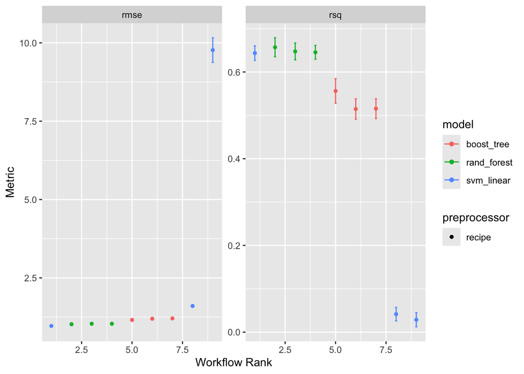

```r
## Visualize the performance of each model
autoplot(coffee_resamples)
```

```r
## Rank the models based on Root Mean Squared Error (RMSE)
## This identifies models that minimizes prediction error
rank_results(coffee_resamples, rank_metric = "rmse")
```

```
## # A tibble: 18 × 9
##    wflow_id        .config .metric   mean std_err     n preprocessor model  rank
##    <chr>           <chr>   <chr>    <dbl>   <dbl> <int> <chr>        <chr> <int>
##  1 tfidf_stop_nor… Prepro… rmse    0.966  0.0172     10 recipe       svm_…     1
##  2 tfidf_stop_nor… Prepro… rsq     0.644  0.0102     10 recipe       svm_…     1
##  3 tfidf_stop_nor… Prepro… rmse    1.02   0.0271     10 recipe       rand…     2
##  4 tfidf_stop_nor… Prepro… rsq     0.657  0.0134     10 recipe       rand…     2
##  5 tfidf_rf        Prepro… rmse    1.04   0.0270     10 recipe       rand…     3
##  6 tfidf_rf        Prepro… rsq     0.647  0.0119     10 recipe       rand…     3
##  7 tf_rf           Prepro… rmse    1.04   0.0280     10 recipe       rand…     4
##  8 tf_rf           Prepro… rsq     0.645  0.00968    10 recipe       rand…     4
##  9 tfidf_stop_nor… Prepro… rmse    1.16   0.0267     10 recipe       boos…     5
## 10 tfidf_stop_nor… Prepro… rsq     0.556  0.0173     10 recipe       boos…     5
## 11 tfidf_xgb       Prepro… rmse    1.20   0.0234     10 recipe       boos…     6
## 12 tfidf_xgb       Prepro… rsq     0.515  0.0143     10 recipe       boos…     6
## 13 tf_xgb          Prepro… rmse    1.21   0.0239     10 recipe       boos…     7
## 14 tf_xgb          Prepro… rsq     0.515  0.0140     10 recipe       boos…     7
## 15 tfidf_svm       Prepro… rmse    1.60   0.0252     10 recipe       svm_…     8
## 16 tfidf_svm       Prepro… rsq     0.0415 0.00952    10 recipe       svm_…     8
## 17 tf_svm          Prepro… rmse    9.77   0.239      10 recipe       svm_…     9
## 18 tf_svm          Prepro… rsq     0.0285 0.00990    10 recipe       svm_…     9
```

```r
## Rank the models based on R-squared (R²)
## This identifies models that explain the most variance in the data
rank_results(coffee_resamples, rank_metric = "rsq")
```

```
## # A tibble: 18 × 9
##    wflow_id        .config .metric   mean std_err     n preprocessor model  rank
##    <chr>           <chr>   <chr>    <dbl>   <dbl> <int> <chr>        <chr> <int>
##  1 tfidf_stop_nor… Prepro… rmse    1.02   0.0271     10 recipe       rand…     1
##  2 tfidf_stop_nor… Prepro… rsq     0.657  0.0134     10 recipe       rand…     1
##  3 tfidf_rf        Prepro… rmse    1.04   0.0270     10 recipe       rand…     2
##  4 tfidf_rf        Prepro… rsq     0.647  0.0119     10 recipe       rand…     2
##  5 tf_rf           Prepro… rmse    1.04   0.0280     10 recipe       rand…     3
##  6 tf_rf           Prepro… rsq     0.645  0.00968    10 recipe       rand…     3
##  7 tfidf_stop_nor… Prepro… rmse    0.966  0.0172     10 recipe       svm_…     4
##  8 tfidf_stop_nor… Prepro… rsq     0.644  0.0102     10 recipe       svm_…     4
##  9 tfidf_stop_nor… Prepro… rmse    1.16   0.0267     10 recipe       boos…     5
## 10 tfidf_stop_nor… Prepro… rsq     0.556  0.0173     10 recipe       boos…     5
## 11 tf_xgb          Prepro… rmse    1.21   0.0239     10 recipe       boos…     6
## 12 tf_xgb          Prepro… rsq     0.515  0.0140     10 recipe       boos…     6
## 13 tfidf_xgb       Prepro… rmse    1.20   0.0234     10 recipe       boos…     7
## 14 tfidf_xgb       Prepro… rsq     0.515  0.0143     10 recipe       boos…     7
## 15 tfidf_svm       Prepro… rmse    1.60   0.0252     10 recipe       svm_…     8
## 16 tfidf_svm       Prepro… rsq     0.0415 0.00952    10 recipe       svm_…     8
## 17 tf_svm          Prepro… rmse    9.77   0.239      10 recipe       svm_…     9
## 18 tf_svm          Prepro… rsq     0.0285 0.00990    10 recipe       svm_…     9
```

# Final fit

Let’s select the best workflow for reducing error, and make it our final workflow. The `last_fit` function fits the final model on the training data and evaluates it on the test data. You only want to touch the test data once! Only use it when you’re really sure. If the metrics look much worse on your testing data, it’s a sign of overfitting to the training data.

```r
## Create the final workflow with the best preprocessing recipe and model specification
coffee_finalworkflow <- workflow(coffee_rec_tfidf_stop_norm, svm_spec)

## Fit the final model using the training data and evaluate it on the test data
coffee_finalfitted <- last_fit(coffee_finalworkflow, coffee_split)

## Collect and display the metrics evaluated on the *testing* data
collect_metrics(coffee_finalfitted)
```

```
## # A tibble: 2 × 4
##   .metric .estimator .estimate .config
##   <chr>   <chr>          <dbl> <chr>
## 1 rmse    standard       0.922 Preprocessor1_Model1
## 2 rsq     standard       0.647 Preprocessor1_Model1
```

# Visualize results

Extracting the model’s coefficients and visualizing the terms with the highest absolute estimates This helps in understanding which terms (words) are most strongly associated with high or low ratings

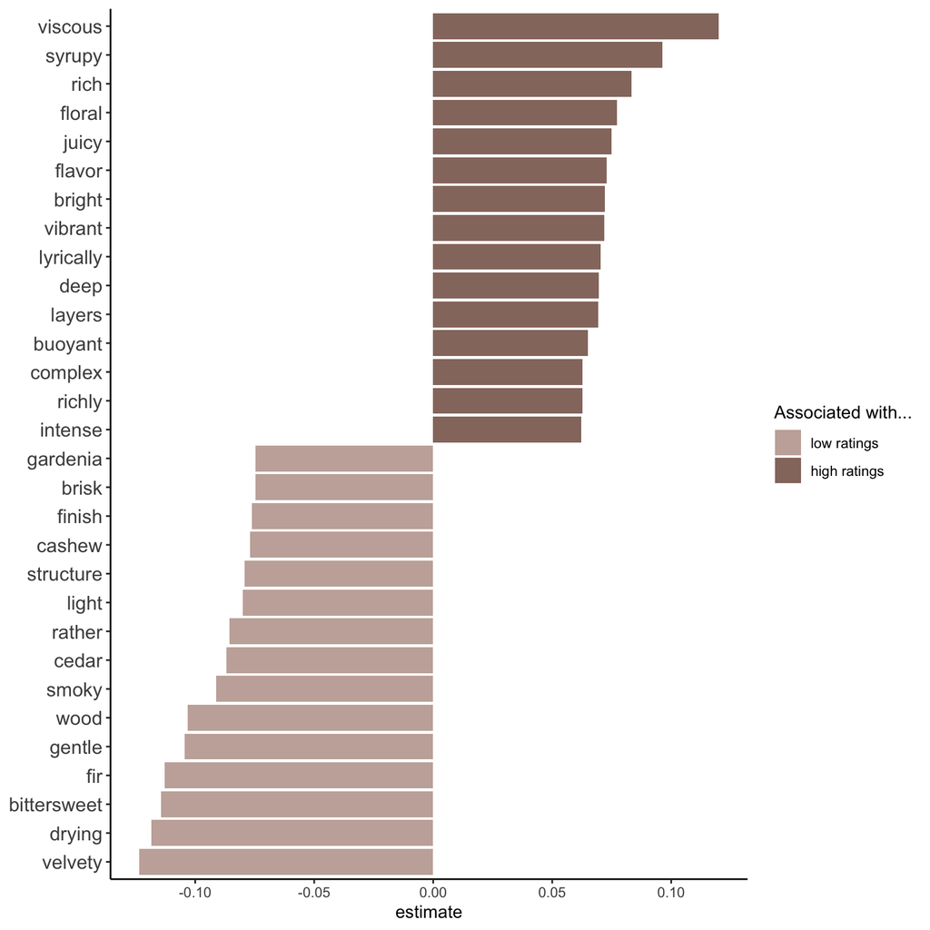

```r
## Extract the final fitted workflow
extract_workflow(coffee_finalfitted) %>%
  ## Convert the model coefficients into a tidy format
  tidy() %>%
  ## Filter out the intercept term
  filter(term != "Bias") %>%
  ## Group by whether the estimate is positive or negative
  group_by(estimate > 0) %>%
  ## Select the top 15 terms with the highest absolute estimates
  slice_max(abs(estimate), n = 15) %>%
  ungroup() %>%
  ## Clean up the term names by removing the prefix
  mutate(term = str_remove(term, "tfidf_review_")) %>%
  ## Create a bar plot of the estimates
  ggplot(aes(estimate, fct_reorder(term, estimate), fill = estimate > 0)) +
  geom_col(alpha = 0.8) +
  ## Manually set pretty coffee colors for positive and negative estimates
  scale_fill_manual(values = c("#B79990", "#784F41"), labels = c("low ratings", "high ratings")) +
  ## Add labels and use a classic theme
  labs(y = NULL, fill = "Associated with...") +
  theme_classic() +
  ## Increase the size of y-axis labels
  theme(axis.text.y = element_text(size = 12))
```

## If I worked for this coffee company, I might recommend avoiding woody notes in the future :)